# Reproducible Research: Peer Assessment 1

## Loading and preprocessing the data

Read the file activity.csv, in the current working directory, and load the results into a dataframe called activity.

```r
activity <- read.csv("activity.csv")
```

## What is mean total number of steps taken by day?

Plot a histogram of total steps by day. Then calculate the mean and median of the daily totals.

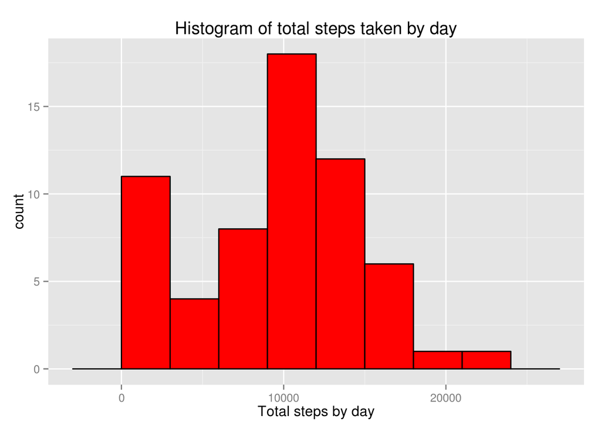

```r
# calculate the sum of steps for each day
total.steps.by.day <- tapply(activity$steps, activity$date, sum, na.rm=T)
# create a histogram
library(ggplot2)
ggplot(NULL, aes(x=total.steps.by.day)) +
    geom_histogram(binwidth=3000, fill="red", colour="black") +
    ggtitle("Histogram of total steps taken by day") +
    xlab("Total steps by day")
```

```r
# calculate the mean and median for the sum of steps by day
cat("The mean is ", mean(total.steps.by.day), "\n", sep="")
```

```
## The mean is 9354
```

```r
cat("The median is ", median(total.steps.by.day), "\n", sep="")
```

```
## The median is 10395
```

The histogram looks like it may be bell-shaped, except that it has a high count in the first interval.

The median is 10395 and the mean is 9354 total steps per day.

## What is the average daily activity pattern?

Plot a time series of average steps by five-minute interval over the course of a day. Then find the maximum point (highest average number of steps per five-minute interval).

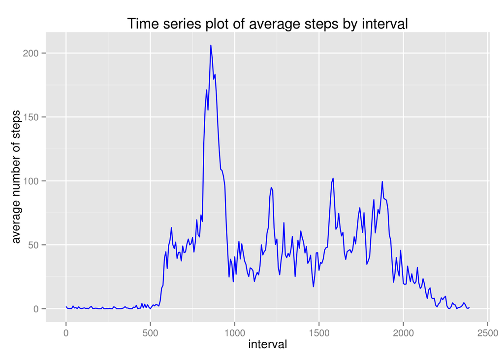

```r
# calculate the sum of steps for each interval
mean.steps.by.interval <- tapply(activity$steps, activity$interval, mean, na.rm=T)
interval <- as.numeric(names(mean.steps.by.interval))
# adjust to use on standard numeric scale (ex: convert 9:30, coded 930, to 950)
interval <- (interval %/% 100 + (interval %% 100) / 60) * 100
# create a time series plot
ggplot(NULL, aes(x = interval, y = mean.steps.by.interval)) +
    geom_line(colour="blue") + ggtitle("Time series plot of average steps by interval") +
    ylab("average number of steps")
```

```r
# find the maximum point
max.interval <- names(mean.steps.by.interval)[which.max(mean.steps.by.interval)]
cat("interval: ", max.interval, ", value: ", mean.steps.by.interval[max.interval], sep="")
```

```
## interval: 835, value: 206.2
```

The greatest number of steps are taken between 8:35 and 8:40 AM. This may be the time many of the participants in the study are leaving for or arriving at work. Few steps are taken between midnight and 6:00 AM, the time when most people are probably asleep.

## Imputing missing values

The number of missing values can be calculated as follows:

```r
# a summary view of the activity dataframe will show that only the steps column has NAs
# subset the dataframe where steps = NA
steps.na <- activity[is.na(activity$steps),]
# report the number of
(missing.value.count <- nrow(steps.na))
```

```
## [1] 2304
```

We see that there are 2304 missing values in the dataset.

The strategy used to fill in the missing values will involve simple substitution using the median. The first six rows of the resulting dataset are shown in the output below.

```r
median.per.interval <- tapply(activity$steps, activity$interval, median, na.rm=T)
activity.with.imputed.values <- activity
# this still requires vectorization
for (i in 1:nrow(activity.with.imputed.values)) {
    if (is.na(activity.with.imputed.values$steps[i])) {
        activity.with.imputed.values$steps[i] <-
            median.per.interval[as.character(activity.with.imputed.values$interval[i])]
    }
}
rm(i)
head(activity.with.imputed.values)
```

```
##   steps       date interval
## 1     0 2012-10-01        0
## 2     0 2012-10-01        5
## 3     0 2012-10-01       10
## 4     0 2012-10-01       15
## 5     0 2012-10-01       20
## 6     0 2012-10-01       25
```

Now let’s look at a histogram for the new dataset.

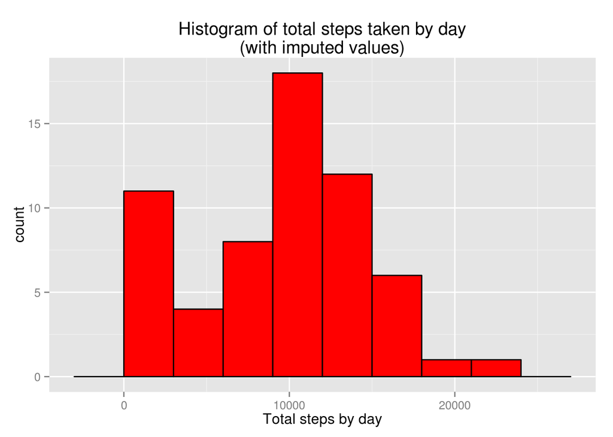

```r
total.steps.by.day.imp <- tapply(activity.with.imputed.values$steps,
                                 activity.with.imputed.values$date, sum)
ggplot(NULL, aes(x=total.steps.by.day.imp)) +
    geom_histogram(binwidth=3000, fill="red", colour="black") +
    ggtitle("Histogram of total steps taken by day\n(with imputed values)") +
    xlab("Total steps by day")
```

```r
# calculate the mean and median for the sum of steps by day
cat("The mean is ", mean(total.steps.by.day.imp), "\n", sep="")
```

```
## The mean is 9504
```

```r
cat("The median is ", median(total.steps.by.day.imp), "\n", sep="")
```

```
## The median is 10395
```

The new histogram looks very similar to the first histogram. The median is the same, 10395, but the mean has increased from 9354 to 9504.

## Are there differences in activity patterns between weekdays and weekends?

Start by created a factor indicating whether a day is classified as a weekday or weekend. View the head of the dataframe to see if the calculations make sense.

```r
# convert the date column to the Date datatype
activity.with.imputed.values$date <- as.Date(activity.with.imputed.values$date)
# use the weekdays function to get the day of the week
# add as a column to the dataframe
activity.with.imputed.values$day.text <- weekdays(activity.with.imputed.values$date)
# use the day.text column, just added, to create a factor with levels "weekend" and "weekday"
activity.with.imputed.values$day.type <-
    factor(ifelse(activity.with.imputed.values$day.text == "Saturday" |
                      activity.with.imputed.values$day.text == "Sunday",
                  "weekend", "weekday"))
# view the results
head(activity.with.imputed.values)
```

```
##   steps       date interval day.text day.type
## 1     0 2012-10-01        0   Monday  weekday
## 2     0 2012-10-01        5   Monday  weekday
## 3     0 2012-10-01       10   Monday  weekday
## 4     0 2012-10-01       15   Monday  weekday
## 5     0 2012-10-01       20   Monday  weekday
## 6     0 2012-10-01       25   Monday  weekday
```

Now create a panel plot containing time series plots by day type.

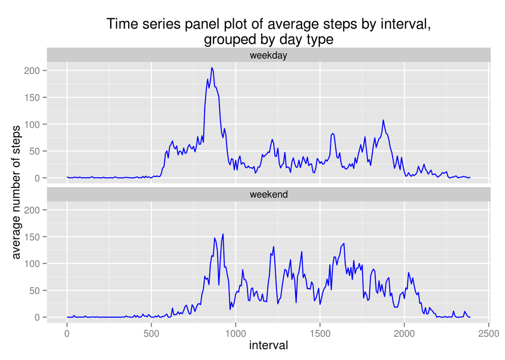

```r
# break the data frame into two parts, using day.type as a separator
df.list <- split(activity.with.imputed.values, activity.with.imputed.values$day.type)
# calculate the sum of steps for each interval
mean.steps <- lapply(df.list, function(x) { tapply(x$steps, x$interval, mean, na.rm=T) })
create.df <- function(v) {
    interval <- as.numeric(names(v))
    # adjust to use on standard numeric scale (ex: convert 9:30, coded 930, to 950)
    interval <- (interval %/% 100 + (interval %% 100) / 60) * 100
    return(data.frame(mean.steps=v, interval=interval))
}
df.list <- lapply(mean.steps, create.df)
for (i in 1:2) {
    df.list[[i]]$day.type <- rep(names(mean.steps)[i], length(nrow(df.list[[i]])))
}
df.all <- rbind(df.list[[1]], df.list[[2]])
# now create the panel plot
ggplot(df.all, aes(x = interval, y = mean.steps, group = day.type)) +
    geom_line(colour="blue") +
    ggtitle("Time series panel plot of average steps by interval,\ngrouped by day type") +
    ylab("average number of steps") +
    facet_wrap( ~ day.type, ncol=1)
```

The weekday time series plot has higher peaks, especially in the morning, but the weekend plot shows that more steps are taken in between the morning and afternoon. This may be because many participants are sitting at their desks during working hours.